# week_03_tidy_bobross

## CMPINF 2110 Spring 2022 - Week 03

### Tidying 538's Bob Ross Data set

## Import Modules

```python
import numpy as np
import pandas as pd
import matplotlib.pyplot as plt

import seaborn as sns
```

## Read data

```python
data_url = 'https://raw.githubusercontent.com/fivethirtyeight/data/master/bob-ross/elements-by-episode.csv'

df = pd.read_csv(data_url)
```

```python
df.shape
```

```
(403, 69)
```

```python
df.columns
```

```
Index(['EPISODE', 'TITLE', 'APPLE_FRAME', 'AURORA_BOREALIS', 'BARN', 'BEACH',
       'BOAT', 'BRIDGE', 'BUILDING', 'BUSHES', 'CABIN', 'CACTUS',
       'CIRCLE_FRAME', 'CIRRUS', 'CLIFF', 'CLOUDS', 'CONIFER', 'CUMULUS',
       'DECIDUOUS', 'DIANE_ANDRE', 'DOCK', 'DOUBLE_OVAL_FRAME', 'FARM',
       'FENCE', 'FIRE', 'FLORIDA_FRAME', 'FLOWERS', 'FOG', 'FRAMED', 'GRASS',
       'GUEST', 'HALF_CIRCLE_FRAME', 'HALF_OVAL_FRAME', 'HILLS', 'LAKE',
       'LAKES', 'LIGHTHOUSE', 'MILL', 'MOON', 'MOUNTAIN', 'MOUNTAINS', 'NIGHT',
       'OCEAN', 'OVAL_FRAME', 'PALM_TREES', 'PATH', 'PERSON', 'PORTRAIT',
       'RECTANGLE_3D_FRAME', 'RECTANGULAR_FRAME', 'RIVER', 'ROCKS',
       'SEASHELL_FRAME', 'SNOW', 'SNOWY_MOUNTAIN', 'SPLIT_FRAME', 'STEVE_ROSS',
       'STRUCTURE', 'SUN', 'TOMB_FRAME', 'TREE', 'TREES', 'TRIPLE_FRAME',
       'WATERFALL', 'WAVES', 'WINDMILL', 'WINDOW_FRAME', 'WINTER',
       'WOOD_FRAMED'],
      dtype='object')
```

```python
df.head()
```

|  | EPISODE | TITLE | APPLE_FRAME | AURORA_BOREALIS | BARN | BEACH | BOAT | BRIDGE | BUILDING | BUSHES | ... | TOMB_FRAME | TREE | TREES | TRIPLE_FRAME | WATERFALL | WAVES | WINDMILL | WINDOW_FRAME | WINTER | WOOD_FRAMED |
| --- | --- | --- | --- | --- | --- | --- | --- | --- | --- | --- | --- | --- | --- | --- | --- | --- | --- | --- | --- | --- | --- |
| 0 | S01E01 | "A WALK IN THE WOODS" | 0 | 0 | 0 | 0 | 0 | 0 | 0 | 1 | ... | 0 | 1 | 1 | 0 | 0 | 0 | 0 | 0 | 0 | 0 |
| 1 | S01E02 | "MT. MCKINLEY" | 0 | 0 | 0 | 0 | 0 | 0 | 0 | 0 | ... | 0 | 1 | 1 | 0 | 0 | 0 | 0 | 0 | 1 | 0 |
| 2 | S01E03 | "EBONY SUNSET" | 0 | 0 | 0 | 0 | 0 | 0 | 0 | 0 | ... | 0 | 1 | 1 | 0 | 0 | 0 | 0 | 0 | 1 | 0 |
| 3 | S01E04 | "WINTER MIST" | 0 | 0 | 0 | 0 | 0 | 0 | 0 | 1 | ... | 0 | 1 | 1 | 0 | 0 | 0 | 0 | 0 | 0 | 0 |
| 4 | S01E05 | "QUIET STREAM" | 0 | 0 | 0 | 0 | 0 | 0 | 0 | 0 | ... | 0 | 1 | 1 | 0 | 0 | 0 | 0 | 0 | 0 | 0 |

5 rows × 69 columns

a value of 0 means the feature identified by the column header is NOT present in the painting.

a value of 1 means the feature identified by the column header IS present in the painting.

```python
df.BARN.sum()
```

```
17
```

```python
df.MOUNTAIN.sum()
```

```
160
```

```python
df.CLOUDS.sum()
```

```
179
```

**What is the observational unit????**

A painting, painted by an artist, in an episode of a season of a show, containing a specific feature.

Check are there missing values?

```python
df.isna().sum()
```

```
EPISODE            0
TITLE              0
APPLE_FRAME        0
AURORA_BOREALIS    0
BARN               0
                  ..
WAVES              0
WINDMILL           0
WINDOW_FRAME       0
WINTER             0
WOOD_FRAMED        0
Length: 69, dtype: int64
```

```python
df.isna().sum().value_counts()
```

```
0    69
dtype: int64
```

```python
df.info()
```

```
<class 'pandas.core.frame.DataFrame'>
RangeIndex: 403 entries, 0 to 402
Data columns (total 69 columns):
 #   Column              Non-Null Count  Dtype
---  ------              --------------  -----
 0   EPISODE             403 non-null    object
 1   TITLE               403 non-null    object
 2   APPLE_FRAME         403 non-null    int64
 3   AURORA_BOREALIS     403 non-null    int64
 4   BARN                403 non-null    int64
 5   BEACH               403 non-null    int64
 6   BOAT                403 non-null    int64
 7   BRIDGE              403 non-null    int64
 8   BUILDING            403 non-null    int64
 9   BUSHES              403 non-null    int64
```

[output cut: 61 more lines]

## Tidy episode labels

Start by examining the `EPISODE` variable. First, confirm that one row corresponds to one episode.

```python
df.EPISODE.value_counts()
```

```
S01E01    1
S21E06    1
S22E03    1
S22E02    1
S22E01    1
         ..
S11E02    1
S11E01    1
S10E13    1
S10E12    1
S31E13    1
Name: EPISODE, Length: 403, dtype: int64
```

```python
df.EPISODE.value_counts().value_counts()
```

```
1    403
Name: EPISODE, dtype: int64
```

```python
df.shape[0]
```

```
403
```

So yes, one row corresponds to one episode.

The `EPISODE` column contains TWO variables! The Season and the Episode within that Season are stored.

We can **split** the `EPISODE` column into a season and episode label by exploiting the pattern.

```python
df.EPISODE.str.split( 'E' )
```

```
0      [S01, 01]
1      [S01, 02]
2      [S01, 03]
3      [S01, 04]
4      [S01, 05]
         ...
398    [S31, 09]
399    [S31, 10]
400    [S31, 11]
401    [S31, 12]
402    [S31, 13]
Name: EPISODE, Length: 403, dtype: object
```

Create new columns associated with the season and the episode within the season.

```python
df_copy = df.copy()
```

```python
df_copy[['season_word', 'episode']] = df_copy.EPISODE.str.split( 'E', expand=True )
```

```python
df_copy.loc[:, ['EPISODE', 'season_word', 'episode']]
```

|  | EPISODE | season_word | episode |
| --- | --- | --- | --- |
| 0 | S01E01 | S01 | 01 |
| 1 | S01E02 | S01 | 02 |
| 2 | S01E03 | S01 | 03 |
| 3 | S01E04 | S01 | 04 |
| 4 | S01E05 | S01 | 05 |
| ... | ... | ... | ... |
| 398 | S31E09 | S31 | 09 |
| 399 | S31E10 | S31 | 10 |
| 400 | S31E11 | S31 | 11 |
| 401 | S31E12 | S31 | 12 |
| 402 | S31E13 | S31 | 13 |

403 rows × 3 columns

Check what `expand=True` does.

```python
df.EPISODE.str.split('E')
```

```
0      [S01, 01]
1      [S01, 02]
2      [S01, 03]
3      [S01, 04]
4      [S01, 05]
         ...
398    [S31, 09]
399    [S31, 10]
400    [S31, 11]
401    [S31, 12]
402    [S31, 13]
Name: EPISODE, Length: 403, dtype: object
```

```python
df.EPISODE.str.split('E', expand=True)
```

|  | 0 | 1 |
| --- | --- | --- |
| 0 | S01 | 01 |
| 1 | S01 | 02 |
| 2 | S01 | 03 |
| 3 | S01 | 04 |
| 4 | S01 | 05 |
| ... | ... | ... |
| 398 | S31 | 09 |
| 399 | S31 | 10 |
| 400 | S31 | 11 |
| 401 | S31 | 12 |
| 402 | S31 | 13 |

403 rows × 2 columns

How many unique seasons are there? How many episodes are there per season?

```python
df_copy.season_word.value_counts()
```

```
S01    13
S17    13
S30    13
S29    13
S28    13
S27    13
S26    13
S25    13
S24    13
S23    13
S22    13
S21    13
S20    13
S19    13
S18    13
S16    13
S02    13
S15    13
S14    13
S13    13
S12    13
S11    13
S10    13
S09    13
S08    13
S07    13
S06    13
S05    13
S04    13
S03    13
S31    13
Name: season_word, dtype: int64
```

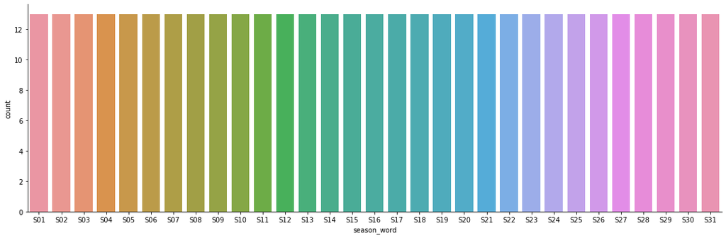

```python
sns.catplot(data = df_copy, x='season_word', kind='count', aspect=3)

plt.show()
```

What if we don't want to store the season as a string? What if we want the number 1 through 31?

Split again based on the pattern `'S'`.

```python
df_copy.season_word.str.split('S')
```

```
0      [, 01]
1      [, 01]
2      [, 01]
3      [, 01]
4      [, 01]
        ...
398    [, 31]
399    [, 31]
400    [, 31]
401    [, 31]
402    [, 31]
Name: season_word, Length: 403, dtype: object
```

```python
df_copy.season_word.str.split('S', expand=True)
```

|  | 0 | 1 |
| --- | --- | --- |
| 0 |  | 01 |
| 1 |  | 01 |
| 2 |  | 01 |
| 3 |  | 01 |
| 4 |  | 01 |
| ... | ... | ... |
| 398 |  | 31 |
| 399 |  | 31 |
| 400 |  | 31 |
| 401 |  | 31 |
| 402 |  | 31 |

403 rows × 2 columns

We could also use **REGULAR EXPRESSIONS** to extract the digit pattern from the string.

## Regular Expressions

Regular expressions are ways of defining patterns of characters to be manipulated in some way from a larger string.

If you want to know more please see:

https://docs.python.org/3/library/re.html

The regular expression or **regex** is a pattern supplied to methods such as `.str.extract()`.

The documentation for the `.str.extract()` method:

https://pandas.pydata.org/pandas-docs/stable/reference/api/pandas.Series.str.extract.html

```python
df_copy.season_word.str.extract( '(0)' )
```

|  | 0 |
| --- | --- |
| 0 | 0 |
| 1 | 0 |
| 2 | 0 |
| 3 | 0 |
| 4 | 0 |
| ... | ... |
| 398 | NaN |
| 399 | NaN |
| 400 | NaN |
| 401 | NaN |
| 402 | NaN |

403 rows × 1 columns

```python
df_copy.season_word.str.extract( '(3)' )
```

|  | 0 |
| --- | --- |
| 0 | NaN |
| 1 | NaN |
| 2 | NaN |
| 3 | NaN |
| 4 | NaN |
| ... | ... |
| 398 | 3 |
| 399 | 3 |
| 400 | 3 |
| 401 | 3 |
| 402 | 3 |

403 rows × 1 columns

```python
df_copy.season_word.str.extract( '(1)' )
```

|  | 0 |
| --- | --- |
| 0 | 1 |
| 1 | 1 |
| 2 | 1 |
| 3 | 1 |
| 4 | 1 |
| ... | ... |
| 398 | 1 |
| 399 | 1 |
| 400 | 1 |
| 401 | 1 |
| 402 | 1 |

403 rows × 1 columns

To extract a collection from a set of possible characters, we need to define the set with the `[]`.

```python
df_copy.season_word.str.extract( '([0])' )
```

|  | 0 |
| --- | --- |
| 0 | 0 |
| 1 | 0 |
| 2 | 0 |
| 3 | 0 |
| 4 | 0 |
| ... | ... |
| 398 | NaN |
| 399 | NaN |
| 400 | NaN |
| 401 | NaN |
| 402 | NaN |

403 rows × 1 columns

I want to find all digits between 0 and 9.

```python
df_copy.season_word.str.extract( '([0-9])')
```

|  | 0 |
| --- | --- |
| 0 | 0 |
| 1 | 0 |
| 2 | 0 |
| 3 | 0 |
| 4 | 0 |
| ... | ... |
| 398 | 3 |
| 399 | 3 |
| 400 | 3 |
| 401 | 3 |
| 402 | 3 |

403 rows × 1 columns

To extract **ALL** characters matching the pattern we need to include the `+`.

```python
df_copy.season_word.str.extract( '([0-9]+)')
```

|  | 0 |
| --- | --- |
| 0 | 01 |
| 1 | 01 |
| 2 | 01 |
| 3 | 01 |
| 4 | 01 |
| ... | ... |
| 398 | 31 |
| 399 | 31 |
| 400 | 31 |
| 401 | 31 |
| 402 | 31 |

403 rows × 1 columns

To extract letters we need to supply the set within the `[]`.

```python
df_copy.season_word.str.extract( '([A-Z])' )
```

|  | 0 |
| --- | --- |
| 0 | S |
| 1 | S |
| 2 | S |
| 3 | S |
| 4 | S |
| ... | ... |
| 398 | S |
| 399 | S |
| 400 | S |
| 401 | S |
| 402 | S |

403 rows × 1 columns

```python
df_copy.season_word.str.extract( '([a-z])' )
```

|  | 0 |
| --- | --- |
| 0 | NaN |
| 1 | NaN |
| 2 | NaN |
| 3 | NaN |
| 4 | NaN |
| ... | ... |
| 398 | NaN |
| 399 | NaN |
| 400 | NaN |
| 401 | NaN |
| 402 | NaN |

403 rows × 1 columns

```python
df_copy.season_word.str.extract( '([a-zA-Z])' )
```

|  | 0 |
| --- | --- |
| 0 | S |
| 1 | S |
| 2 | S |
| 3 | S |
| 4 | S |
| ... | ... |
| 398 | S |
| 399 | S |
| 400 | S |
| 401 | S |
| 402 | S |

403 rows × 1 columns

I prefer the "shortcuts" within **regex**. To find a digit we can use the `\d` and to find **ALL digits** we use `\d+`.

```python
df_copy.EPISODE.str.extract( '(\d+)' )
```

|  | 0 |
| --- | --- |
| 0 | 01 |
| 1 | 01 |
| 2 | 01 |
| 3 | 01 |
| 4 | 01 |
| ... | ... |
| 398 | 31 |
| 399 | 31 |
| 400 | 31 |
| 401 | 31 |
| 402 | 31 |

403 rows × 1 columns

We can create rather complex regular expressions. For example, we could have extracted the season and the episode ID directly from the original `EPISODE` column.

```python
df.EPISODE.str.extract( '(\d+)+[a-zA-Z]+(\d+)' )
```

|  | 0 | 1 |
| --- | --- | --- |
| 0 | 01 | 01 |
| 1 | 01 | 02 |
| 2 | 01 | 03 |
| 3 | 01 | 04 |
| 4 | 01 | 05 |
| ... | ... | ... |
| 398 | 31 | 09 |
| 399 | 31 | 10 |
| 400 | 31 | 11 |
| 401 | 31 | 12 |
| 402 | 31 | 13 |

403 rows × 2 columns

Recommendation: use split to "break up" a complicated string and exploit common patterns. Then apply **regex** to simpler strings.

```python
df_copy['season'] = df_copy.season_word.str.extract( '(\d+)', expand=False)
```

```python
df_copy.loc[:, ['EPISODE', 'season_word', 'season', 'episode']]
```

|  | EPISODE | season_word | season | episode |
| --- | --- | --- | --- | --- |
| 0 | S01E01 | S01 | 01 | 01 |
| 1 | S01E02 | S01 | 01 | 02 |
| 2 | S01E03 | S01 | 01 | 03 |
| 3 | S01E04 | S01 | 01 | 04 |
| 4 | S01E05 | S01 | 01 | 05 |
| ... | ... | ... | ... | ... |
| 398 | S31E09 | S31 | 31 | 09 |
| 399 | S31E10 | S31 | 31 | 10 |
| 400 | S31E11 | S31 | 31 | 11 |
| 401 | S31E12 | S31 | 31 | 12 |
| 402 | S31E13 | S31 | 31 | 13 |

403 rows × 4 columns

Check the data types.

```python
df_copy.loc[:, ['EPISODE', 'season_word', 'season', 'episode']].info()
```

```
<class 'pandas.core.frame.DataFrame'>
RangeIndex: 403 entries, 0 to 402
Data columns (total 4 columns):
 #   Column       Non-Null Count  Dtype
---  ------       --------------  -----
 0   EPISODE      403 non-null    object
 1   season_word  403 non-null    object
 2   season       403 non-null    object
 3   episode      403 non-null    object
dtypes: object(4)
memory usage: 12.7+ KB
```

Convert from strings to integers.

```python
df_copy['season'] = df_copy.season.astype('int64')
df_copy['episode'] = df_copy.episode.astype('int64')
```

```python
df_copy.loc[:, ['EPISODE', 'season_word', 'season', 'episode']].info()
```

```
<class 'pandas.core.frame.DataFrame'>
RangeIndex: 403 entries, 0 to 402
Data columns (total 4 columns):
 #   Column       Non-Null Count  Dtype
---  ------       --------------  -----
 0   EPISODE      403 non-null    object
 1   season_word  403 non-null    object
 2   season       403 non-null    int64
 3   episode      403 non-null    int64
dtypes: int64(2), object(2)
memory usage: 12.7+ KB
```

The original `EPISODE` column and the `season_word` column are redundant, drop them.

```python
df_copy.drop(columns=['EPISODE', 'season_word'], inplace=True)
```

```python
df_copy.columns
```

```
Index(['TITLE', 'APPLE_FRAME', 'AURORA_BOREALIS', 'BARN', 'BEACH', 'BOAT',
       'BRIDGE', 'BUILDING', 'BUSHES', 'CABIN', 'CACTUS', 'CIRCLE_FRAME',
       'CIRRUS', 'CLIFF', 'CLOUDS', 'CONIFER', 'CUMULUS', 'DECIDUOUS',
       'DIANE_ANDRE', 'DOCK', 'DOUBLE_OVAL_FRAME', 'FARM', 'FENCE', 'FIRE',
       'FLORIDA_FRAME', 'FLOWERS', 'FOG', 'FRAMED', 'GRASS', 'GUEST',
       'HALF_CIRCLE_FRAME', 'HALF_OVAL_FRAME', 'HILLS', 'LAKE', 'LAKES',
       'LIGHTHOUSE', 'MILL', 'MOON', 'MOUNTAIN', 'MOUNTAINS', 'NIGHT', 'OCEAN',
       'OVAL_FRAME', 'PALM_TREES', 'PATH', 'PERSON', 'PORTRAIT',
       'RECTANGLE_3D_FRAME', 'RECTANGULAR_FRAME', 'RIVER', 'ROCKS',
       'SEASHELL_FRAME', 'SNOW', 'SNOWY_MOUNTAIN', 'SPLIT_FRAME', 'STEVE_ROSS',
       'STRUCTURE', 'SUN', 'TOMB_FRAME', 'TREE', 'TREES', 'TRIPLE_FRAME',
       'WATERFALL', 'WAVES', 'WINDMILL', 'WINDOW_FRAME', 'WINTER',
       'WOOD_FRAMED', 'episode', 'season'],
      dtype='object')
```

All other columns are unaffected.

```python
df_copy.BARN.sum()
```

```
17
```

We can calculate the number of BARNs painted per season.

```python
df_copy.groupby(['season']).\
aggregate(num_barns = ('BARN', 'sum')).\
reset_index()
```

|  | season | num_barns |
| --- | --- | --- |
| 0 | 1 | 0 |
| 1 | 2 | 0 |
| 2 | 3 | 1 |
| 3 | 4 | 0 |
| 4 | 5 | 2 |
| 5 | 6 | 1 |
| 6 | 7 | 1 |
| 7 | 8 | 0 |
| 8 | 9 | 0 |
| 9 | 10 | 0 |
| 10 | 11 | 3 |
| 11 | 12 | 0 |
| 12 | 13 | 0 |
| 13 | 14 | 0 |
| 14 | 15 | 1 |
| 15 | 16 | 1 |
| 16 | 17 | 0 |
| 17 | 18 | 0 |
| 18 | 19 | 1 |
| 19 | 20 | 1 |
| 20 | 21 | 0 |
| 21 | 22 | 1 |
| 22 | 23 | 0 |
| 23 | 24 | 0 |
| 24 | 25 | 0 |
| 25 | 26 | 0 |
| 26 | 27 | 0 |
| 27 | 28 | 2 |
| 28 | 29 | 1 |
| 29 | 30 | 0 |
| 30 | 31 | 1 |

Manually check this is grouping and aggregation is correct.

```python
df_copy.loc[ df_copy.season == 11, ['season', 'episode', 'BARN']]
```

|  | season | episode | BARN |
| --- | --- | --- | --- |
| 130 | 11 | 1 | 0 |
| 131 | 11 | 2 | 0 |
| 132 | 11 | 3 | 0 |
| 133 | 11 | 4 | 0 |
| 134 | 11 | 5 | 0 |
| 135 | 11 | 6 | 1 |
| 136 | 11 | 7 | 0 |
| 137 | 11 | 8 | 0 |
| 138 | 11 | 9 | 1 |
| 139 | 11 | 10 | 0 |
| 140 | 11 | 11 | 0 |
| 141 | 11 | 12 | 1 |
| 142 | 11 | 13 | 0 |

## Artists

The original data set has columns with several artist names.

```python
people = df_copy.loc[:, ['season', 'episode', 'DIANE_ANDRE', 'GUEST', 'STEVE_ROSS']].copy()
```

```python
people
```

|  | season | episode | DIANE_ANDRE | GUEST | STEVE_ROSS |
| --- | --- | --- | --- | --- | --- |
| 0 | 1 | 1 | 0 | 0 | 0 |
| 1 | 1 | 2 | 0 | 0 | 0 |
| 2 | 1 | 3 | 0 | 0 | 0 |
| 3 | 1 | 4 | 0 | 0 | 0 |
| 4 | 1 | 5 | 0 | 0 | 0 |
| ... | ... | ... | ... | ... | ... |
| 398 | 31 | 9 | 0 | 0 | 0 |
| 399 | 31 | 10 | 0 | 0 | 0 |
| 400 | 31 | 11 | 0 | 1 | 1 |
| 401 | 31 | 12 | 0 | 0 | 0 |
| 402 | 31 | 13 | 0 | 0 | 0 |

403 rows × 5 columns

Before tidying the artists, let's look at the combination of the values for each of the artist columns.

```python
people.groupby(['DIANE_ANDRE', 'GUEST', 'STEVE_ROSS']).size().reset_index(name='num_rows')
```

|  | DIANE_ANDRE | GUEST | STEVE_ROSS | num_rows |
| --- | --- | --- | --- | --- |
| 0 | 0 | 0 | 0 | 381 |
| 1 | 0 | 1 | 0 | 10 |
| 2 | 0 | 1 | 1 | 11 |
| 3 | 1 | 1 | 0 | 1 |

To overcome the weird behavior of the `GUEST` column, we need to identify all paintings painted by Bob Ross.

```python
people['BOB_ROSS'] = np.where( people.GUEST == 0, 1, 0 )
```

```python
people
```

|  | season | episode | DIANE_ANDRE | GUEST | STEVE_ROSS | BOB_ROSS |
| --- | --- | --- | --- | --- | --- | --- |
| 0 | 1 | 1 | 0 | 0 | 0 | 1 |
| 1 | 1 | 2 | 0 | 0 | 0 | 1 |
| 2 | 1 | 3 | 0 | 0 | 0 | 1 |
| 3 | 1 | 4 | 0 | 0 | 0 | 1 |
| 4 | 1 | 5 | 0 | 0 | 0 | 1 |
| ... | ... | ... | ... | ... | ... | ... |
| 398 | 31 | 9 | 0 | 0 | 0 | 1 |
| 399 | 31 | 10 | 0 | 0 | 0 | 1 |
| 400 | 31 | 11 | 0 | 1 | 1 | 0 |
| 401 | 31 | 12 | 0 | 0 | 0 | 1 |
| 402 | 31 | 13 | 0 | 0 | 0 | 1 |

403 rows × 6 columns

Check the combinations.

```python
people.groupby(['DIANE_ANDRE', 'GUEST', 'STEVE_ROSS', 'BOB_ROSS']).size().reset_index(name='num_rows')
```

|  | DIANE_ANDRE | GUEST | STEVE_ROSS | BOB_ROSS | num_rows |
| --- | --- | --- | --- | --- | --- |
| 0 | 0 | 0 | 0 | 1 | 381 |
| 1 | 0 | 1 | 0 | 0 | 10 |
| 2 | 0 | 1 | 1 | 0 | 11 |
| 3 | 1 | 1 | 0 | 0 | 1 |

We can now identify when someone not named in the present data set was the painter. Create a new column `OTHER` to denote when someone we do not know painted the painting that episode. The following approach works because all columns are 0 or 1.

```python
people['OTHER'] = np.where( people.BOB_ROSS + people.STEVE_ROSS + people.DIANE_ANDRE == 0, 1, 0)
```

```python
people
```

|  | season | episode | DIANE_ANDRE | GUEST | STEVE_ROSS | BOB_ROSS | OTHER |
| --- | --- | --- | --- | --- | --- | --- | --- |
| 0 | 1 | 1 | 0 | 0 | 0 | 1 | 0 |
| 1 | 1 | 2 | 0 | 0 | 0 | 1 | 0 |
| 2 | 1 | 3 | 0 | 0 | 0 | 1 | 0 |
| 3 | 1 | 4 | 0 | 0 | 0 | 1 | 0 |
| 4 | 1 | 5 | 0 | 0 | 0 | 1 | 0 |
| ... | ... | ... | ... | ... | ... | ... | ... |
| 398 | 31 | 9 | 0 | 0 | 0 | 1 | 0 |
| 399 | 31 | 10 | 0 | 0 | 0 | 1 | 0 |
| 400 | 31 | 11 | 0 | 1 | 1 | 0 | 0 |
| 401 | 31 | 12 | 0 | 0 | 0 | 1 | 0 |
| 402 | 31 | 13 | 0 | 0 | 0 | 1 | 0 |

403 rows × 7 columns

As a check look at the combinations again.

```python
people.groupby(['DIANE_ANDRE', 'GUEST', 'OTHER', 'STEVE_ROSS', 'BOB_ROSS']).size().reset_index(name='num_rows')
```

|  | DIANE_ANDRE | GUEST | OTHER | STEVE_ROSS | BOB_ROSS | num_rows |
| --- | --- | --- | --- | --- | --- | --- |
| 0 | 0 | 0 | 0 | 0 | 1 | 381 |
| 1 | 0 | 1 | 0 | 1 | 0 | 11 |
| 2 | 0 | 1 | 1 | 0 | 0 | 10 |
| 3 | 1 | 1 | 0 | 0 | 0 | 1 |

We have created the unique values for the hidden variable "artist". Drop the `GUEST` column.

```python
people.drop(columns=['GUEST'], inplace=True)
```

```python
people
```

|  | season | episode | DIANE_ANDRE | STEVE_ROSS | BOB_ROSS | OTHER |
| --- | --- | --- | --- | --- | --- | --- |
| 0 | 1 | 1 | 0 | 0 | 1 | 0 |
| 1 | 1 | 2 | 0 | 0 | 1 | 0 |
| 2 | 1 | 3 | 0 | 0 | 1 | 0 |
| 3 | 1 | 4 | 0 | 0 | 1 | 0 |
| 4 | 1 | 5 | 0 | 0 | 1 | 0 |
| ... | ... | ... | ... | ... | ... | ... |
| 398 | 31 | 9 | 0 | 0 | 1 | 0 |
| 399 | 31 | 10 | 0 | 0 | 1 | 0 |
| 400 | 31 | 11 | 0 | 1 | 0 | 0 |
| 401 | 31 | 12 | 0 | 0 | 1 | 0 |
| 402 | 31 | 13 | 0 | 0 | 1 | 0 |

403 rows × 6 columns

Reshape from the current wide-format to long-format.

```python
people_lf = people.melt( id_vars=['season', 'episode'],
                         value_vars=['DIANE_ANDRE', 'OTHER', 'STEVE_ROSS', 'BOB_ROSS'],
                         var_name='artist')
```

```python
people_lf
```

|  | season | episode | artist | value |
| --- | --- | --- | --- | --- |
| 0 | 1 | 1 | DIANE_ANDRE | 0 |
| 1 | 1 | 2 | DIANE_ANDRE | 0 |
| 2 | 1 | 3 | DIANE_ANDRE | 0 |
| 3 | 1 | 4 | DIANE_ANDRE | 0 |
| 4 | 1 | 5 | DIANE_ANDRE | 0 |
| ... | ... | ... | ... | ... |
| 1607 | 31 | 9 | BOB_ROSS | 1 |
| 1608 | 31 | 10 | BOB_ROSS | 1 |
| 1609 | 31 | 11 | BOB_ROSS | 0 |
| 1610 | 31 | 12 | BOB_ROSS | 1 |
| 1611 | 31 | 13 | BOB_ROSS | 1 |

1612 rows × 4 columns

```python
df.shape[0] * 4
```

```
1612
```

```python
people_lf.artist.value_counts()
```

```
DIANE_ANDRE    403
OTHER          403
STEVE_ROSS     403
BOB_ROSS       403
Name: artist, dtype: int64
```

We only need to keep the rows of `people_lf` where `value > 0`.

```python
artist_per_episode = people_lf.loc[ people_lf.value > 0, :].copy()
```

```python
artist_per_episode
```

|  | season | episode | artist | value |
| --- | --- | --- | --- | --- |
| 49 | 4 | 11 | DIANE_ANDRE | 1 |
| 445 | 4 | 4 | OTHER | 1 |
| 457 | 5 | 3 | OTHER | 1 |
| 460 | 5 | 6 | OTHER | 1 |
| 463 | 5 | 9 | OTHER | 1 |
| ... | ... | ... | ... | ... |
| 1606 | 31 | 8 | BOB_ROSS | 1 |
| 1607 | 31 | 9 | BOB_ROSS | 1 |
| 1608 | 31 | 10 | BOB_ROSS | 1 |
| 1610 | 31 | 12 | BOB_ROSS | 1 |
| 1611 | 31 | 13 | BOB_ROSS | 1 |

403 rows × 4 columns

Rearrange by season and episode sequential order.

```python
artist_per_episode.sort_values(['season', 'episode'], inplace=True, ignore_index=True)
```

```python
artist_per_episode
```

|  | season | episode | artist | value |
| --- | --- | --- | --- | --- |
| 0 | 1 | 1 | BOB_ROSS | 1 |
| 1 | 1 | 2 | BOB_ROSS | 1 |
| 2 | 1 | 3 | BOB_ROSS | 1 |
| 3 | 1 | 4 | BOB_ROSS | 1 |
| 4 | 1 | 5 | BOB_ROSS | 1 |
| ... | ... | ... | ... | ... |
| 398 | 31 | 9 | BOB_ROSS | 1 |
| 399 | 31 | 10 | BOB_ROSS | 1 |
| 400 | 31 | 11 | STEVE_ROSS | 1 |
| 401 | 31 | 12 | BOB_ROSS | 1 |
| 402 | 31 | 13 | BOB_ROSS | 1 |

403 rows × 4 columns

The `value` column can be dropped.

```python
artist_per_episode.drop(columns=['value'], inplace=True)
```

```python
artist_per_episode
```

|  | season | episode | artist |
| --- | --- | --- | --- |
| 0 | 1 | 1 | BOB_ROSS |
| 1 | 1 | 2 | BOB_ROSS |
| 2 | 1 | 3 | BOB_ROSS |
| 3 | 1 | 4 | BOB_ROSS |
| 4 | 1 | 5 | BOB_ROSS |
| ... | ... | ... | ... |
| 398 | 31 | 9 | BOB_ROSS |
| 399 | 31 | 10 | BOB_ROSS |
| 400 | 31 | 11 | STEVE_ROSS |
| 401 | 31 | 12 | BOB_ROSS |
| 402 | 31 | 13 | BOB_ROSS |

403 rows × 3 columns

We have a dataset with one row per painting (episode) and the artist associated with that episode, we can answer questions.

```python
artist_info = artist_per_episode.\
groupby(['artist']).\
aggregate(num_episodes = ('episode', 'count'),
          num_seasons = ('season', 'nunique'),
          first_season = ('season', 'min'),
          last_season = ('season', 'max')).\
reset_index()
```

```python
artist_info
```

|  | artist | num_episodes | num_seasons | first_season | last_season |
| --- | --- | --- | --- | --- | --- |
| 0 | BOB_ROSS | 381 | 31 | 1 | 31 |
| 1 | DIANE_ANDRE | 1 | 1 | 4 | 4 |
| 2 | OTHER | 10 | 7 | 4 | 29 |
| 3 | STEVE_ROSS | 11 | 11 | 3 | 31 |

## Tidying the features contained in the paintings

Create a data set consisting just of the features and the episode identifiers.

```python
features = df_copy.drop(columns=['DIANE_ANDRE', 'GUEST', 'STEVE_ROSS', 'TITLE']).copy()
```

```python
features.columns
```

```
Index(['APPLE_FRAME', 'AURORA_BOREALIS', 'BARN', 'BEACH', 'BOAT', 'BRIDGE',
       'BUILDING', 'BUSHES', 'CABIN', 'CACTUS', 'CIRCLE_FRAME', 'CIRRUS',
       'CLIFF', 'CLOUDS', 'CONIFER', 'CUMULUS', 'DECIDUOUS', 'DOCK',
       'DOUBLE_OVAL_FRAME', 'FARM', 'FENCE', 'FIRE', 'FLORIDA_FRAME',
       'FLOWERS', 'FOG', 'FRAMED', 'GRASS', 'HALF_CIRCLE_FRAME',
       'HALF_OVAL_FRAME', 'HILLS', 'LAKE', 'LAKES', 'LIGHTHOUSE', 'MILL',
       'MOON', 'MOUNTAIN', 'MOUNTAINS', 'NIGHT', 'OCEAN', 'OVAL_FRAME',
       'PALM_TREES', 'PATH', 'PERSON', 'PORTRAIT', 'RECTANGLE_3D_FRAME',
       'RECTANGULAR_FRAME', 'RIVER', 'ROCKS', 'SEASHELL_FRAME', 'SNOW',
       'SNOWY_MOUNTAIN', 'SPLIT_FRAME', 'STRUCTURE', 'SUN', 'TOMB_FRAME',
       'TREE', 'TREES', 'TRIPLE_FRAME', 'WATERFALL', 'WAVES', 'WINDMILL',
       'WINDOW_FRAME', 'WINTER', 'WOOD_FRAMED', 'episode', 'season'],
      dtype='object')
```

We need to reshape the features wide-format data set into a long-format.

We need a list of just the feature values or labels.

```python
features.columns
```

```
Index(['APPLE_FRAME', 'AURORA_BOREALIS', 'BARN', 'BEACH', 'BOAT', 'BRIDGE',
       'BUILDING', 'BUSHES', 'CABIN', 'CACTUS', 'CIRCLE_FRAME', 'CIRRUS',
       'CLIFF', 'CLOUDS', 'CONIFER', 'CUMULUS', 'DECIDUOUS', 'DOCK',
       'DOUBLE_OVAL_FRAME', 'FARM', 'FENCE', 'FIRE', 'FLORIDA_FRAME',
       'FLOWERS', 'FOG', 'FRAMED', 'GRASS', 'HALF_CIRCLE_FRAME',
       'HALF_OVAL_FRAME', 'HILLS', 'LAKE', 'LAKES', 'LIGHTHOUSE', 'MILL',
       'MOON', 'MOUNTAIN', 'MOUNTAINS', 'NIGHT', 'OCEAN', 'OVAL_FRAME',
       'PALM_TREES', 'PATH', 'PERSON', 'PORTRAIT', 'RECTANGLE_3D_FRAME',
       'RECTANGULAR_FRAME', 'RIVER', 'ROCKS', 'SEASHELL_FRAME', 'SNOW',
       'SNOWY_MOUNTAIN', 'SPLIT_FRAME', 'STRUCTURE', 'SUN', 'TOMB_FRAME',
       'TREE', 'TREES', 'TRIPLE_FRAME', 'WATERFALL', 'WAVES', 'WINDMILL',
       'WINDOW_FRAME', 'WINTER', 'WOOD_FRAMED', 'episode', 'season'],
      dtype='object')
```

Easy to identify the values that are the episode identifiers with `.isin()`.

```python
features.columns.isin(['season', 'episode'])
```

```
array([False, False, False, False, False, False, False, False, False,
       False, False, False, False, False, False, False, False, False,
       False, False, False, False, False, False, False, False, False,
       False, False, False, False, False, False, False, False, False,
       False, False, False, False, False, False, False, False, False,
       False, False, False, False, False, False, False, False, False,
       False, False, False, False, False, False, False, False, False,
       False,  True,  True])
```

I want to find the values that are **NOT** "in" the episode identifiers. We get that functionality with the `~` operator.

```python
~features.columns.isin(['season', 'episode'])
```

```
array([ True,  True,  True,  True,  True,  True,  True,  True,  True,
        True,  True,  True,  True,  True,  True,  True,  True,  True,
        True,  True,  True,  True,  True,  True,  True,  True,  True,
        True,  True,  True,  True,  True,  True,  True,  True,  True,
        True,  True,  True,  True,  True,  True,  True,  True,  True,
        True,  True,  True,  True,  True,  True,  True,  True,  True,
        True,  True,  True,  True,  True,  True,  True,  True,  True,
        True, False, False])
```

```python
feature_names = features.columns[ ~features.columns.isin(['season', 'episode'])].to_list()
```

```python
feature_names
```

```
['APPLE_FRAME',
 'AURORA_BOREALIS',
 'BARN',
 'BEACH',
 'BOAT',
 'BRIDGE',
 'BUILDING',
 'BUSHES',
 'CABIN',
 'CACTUS',
 'CIRCLE_FRAME',
 'CIRRUS',
 'CLIFF',
 'CLOUDS',
 'CONIFER',
 'CUMULUS',
 'DECIDUOUS',
 'DOCK',
 'DOUBLE_OVAL_FRAME',
 'FARM',
 'FENCE',
 'FIRE',
 'FLORIDA_FRAME',
 'FLOWERS',
 'FOG',
 'FRAMED',
 'GRASS',
 'HALF_CIRCLE_FRAME',
 'HALF_OVAL_FRAME',
 'HILLS',
 'LAKE',
 'LAKES',
 'LIGHTHOUSE',
 'MILL',
 'MOON',
 'MOUNTAIN',
 'MOUNTAINS',
 'NIGHT',
 'OCEAN',
 'OVAL_FRAME',
```

[output cut: 9 more lines]

```
 'SNOW',
 'SNOWY_MOUNTAIN',
 'SPLIT_FRAME',
 'STRUCTURE',
 'SUN',
 'TOMB_FRAME',
 'TREE',
 'TREES',
 'TRIPLE_FRAME',
 'WATERFALL',
 'WAVES',
 'WINDMILL',
 'WINDOW_FRAME',
 'WINTER',
 'WOOD_FRAMED']
```

Reshape the wide-format features into a long-format data set.

```python
features_lf = features.melt( id_vars=['season', 'episode'], value_vars=feature_names, var_name='feature')
```

```python
features_lf
```

|  | season | episode | feature | value |
| --- | --- | --- | --- | --- |
| 0 | 1 | 1 | APPLE_FRAME | 0 |
| 1 | 1 | 2 | APPLE_FRAME | 0 |
| 2 | 1 | 3 | APPLE_FRAME | 0 |
| 3 | 1 | 4 | APPLE_FRAME | 0 |
| 4 | 1 | 5 | APPLE_FRAME | 0 |
| ... | ... | ... | ... | ... |
| 25787 | 31 | 9 | WOOD_FRAMED | 0 |
| 25788 | 31 | 10 | WOOD_FRAMED | 0 |
| 25789 | 31 | 11 | WOOD_FRAMED | 0 |
| 25790 | 31 | 12 | WOOD_FRAMED | 0 |
| 25791 | 31 | 13 | WOOD_FRAMED | 0 |

25792 rows × 4 columns

```python
len( feature_names ) * df.shape[0]
```

```
25792
```

```python
len( feature_names )
```

```
64
```

I only want to keep the specific features painted in the painting. So only keep rows in `feature_lf` with `value == 1`.

```python
present_features = features_lf.loc[ features_lf.value == 1, :].copy()
```

```python
present_features
```

|  | season | episode | feature | value |
| --- | --- | --- | --- | --- |
| 215 | 17 | 8 | APPLE_FRAME | 1 |
| 506 | 8 | 13 | AURORA_BOREALIS | 1 |
| 778 | 29 | 12 | AURORA_BOREALIS | 1 |
| 842 | 3 | 11 | BARN | 1 |
| 867 | 5 | 10 | BARN | 1 |
| ... | ... | ... | ... | ... |
| 25361 | 29 | 12 | WINTER | 1 |
| 25369 | 30 | 7 | WINTER | 1 |
| 25380 | 31 | 5 | WINTER | 1 |
| 25387 | 31 | 12 | WINTER | 1 |
| 25767 | 30 | 2 | WOOD_FRAMED | 1 |

3187 rows × 4 columns

Rearrange in season and episode seqential order.

```python
present_features.sort_values(['season', 'episode'], inplace=True, ignore_index=True)
```

```python
present_features
```

|  | season | episode | feature | value |
| --- | --- | --- | --- | --- |
| 0 | 1 | 1 | BUSHES | 1 |
| 1 | 1 | 1 | DECIDUOUS | 1 |
| 2 | 1 | 1 | GRASS | 1 |
| 3 | 1 | 1 | RIVER | 1 |
| 4 | 1 | 1 | TREE | 1 |
| ... | ... | ... | ... | ... |
| 3182 | 31 | 13 | DECIDUOUS | 1 |
| 3183 | 31 | 13 | GRASS | 1 |
| 3184 | 31 | 13 | MOUNTAIN | 1 |
| 3185 | 31 | 13 | TREE | 1 |
| 3186 | 31 | 13 | TREES | 1 |

3187 rows × 4 columns

What features are in the first episode of the first season?

```python
present_features.loc[ (present_features.season == 1) & (present_features.episode == 1) ]
```

|  | season | episode | feature | value |
| --- | --- | --- | --- | --- |
| 0 | 1 | 1 | BUSHES | 1 |
| 1 | 1 | 1 | DECIDUOUS | 1 |
| 2 | 1 | 1 | GRASS | 1 |
| 3 | 1 | 1 | RIVER | 1 |
| 4 | 1 | 1 | TREE | 1 |
| 5 | 1 | 1 | TREES | 1 |

What features are present in the last episode of the last season?

```python
present_features.loc[ (present_features.season == present_features.season.max()) & (present_features.episode == present_features.episode.max()) ]
```

|  | season | episode | feature | value |
| --- | --- | --- | --- | --- |
| 3182 | 31 | 13 | DECIDUOUS | 1 |
| 3183 | 31 | 13 | GRASS | 1 |
| 3184 | 31 | 13 | MOUNTAIN | 1 |
| 3185 | 31 | 13 | TREE | 1 |
| 3186 | 31 | 13 | TREES | 1 |

Did we lose any episodes? We reshaped from the wide to the long-format.

We know that the original data set had ZERO missing values.

To help with this check we will break the tidy data rules by including a column which contains multiple entries.

```python
check_seasons_from_features = present_features.groupby(['season']).\
aggregate(num_episodes = ('episode', 'nunique'),
          which_episodes = ('episode', 'unique'),
          min_episode = ('episode', 'min'),
          max_episode = ('episode', 'max')).\
reset_index()
```

```python
check_seasons_from_features
```

|  | season | num_episodes | which_episodes | min_episode | max_episode |
| --- | --- | --- | --- | --- | --- |
| 0 | 1 | 13 | [1, 2, 3, 4, 5, 6, 7, 8, 9, 10, 11, 12, 13] | 1 | 13 |
| 1 | 2 | 13 | [1, 2, 3, 4, 5, 6, 7, 8, 9, 10, 11, 12, 13] | 1 | 13 |
| 2 | 3 | 13 | [1, 2, 3, 4, 5, 6, 7, 8, 9, 10, 11, 12, 13] | 1 | 13 |
| 3 | 4 | 13 | [1, 2, 3, 4, 5, 6, 7, 8, 9, 10, 11, 12, 13] | 1 | 13 |
| 4 | 5 | 13 | [1, 2, 3, 4, 5, 6, 7, 8, 9, 10, 11, 12, 13] | 1 | 13 |
| 5 | 6 | 13 | [1, 2, 3, 4, 5, 6, 7, 8, 9, 10, 11, 12, 13] | 1 | 13 |
| 6 | 7 | 13 | [1, 2, 3, 4, 5, 6, 7, 8, 9, 10, 11, 12, 13] | 1 | 13 |
| 7 | 8 | 13 | [1, 2, 3, 4, 5, 6, 7, 8, 9, 10, 11, 12, 13] | 1 | 13 |
| 8 | 9 | 12 | [1, 2, 3, 4, 5, 6, 7, 8, 9, 11, 12, 13] | 1 | 13 |
| 9 | 10 | 13 | [1, 2, 3, 4, 5, 6, 7, 8, 9, 10, 11, 12, 13] | 1 | 13 |
| 10 | 11 | 13 | [1, 2, 3, 4, 5, 6, 7, 8, 9, 10, 11, 12, 13] | 1 | 13 |
| 11 | 12 | 13 | [1, 2, 3, 4, 5, 6, 7, 8, 9, 10, 11, 12, 13] | 1 | 13 |
| 12 | 13 | 13 | [1, 2, 3, 4, 5, 6, 7, 8, 9, 10, 11, 12, 13] | 1 | 13 |
| 13 | 14 | 13 | [1, 2, 3, 4, 5, 6, 7, 8, 9, 10, 11, 12, 13] | 1 | 13 |
| 14 | 15 | 12 | [1, 2, 3, 5, 6, 7, 8, 9, 10, 11, 12, 13] | 1 | 13 |
| 15 | 16 | 13 | [1, 2, 3, 4, 5, 6, 7, 8, 9, 10, 11, 12, 13] | 1 | 13 |
| 16 | 17 | 13 | [1, 2, 3, 4, 5, 6, 7, 8, 9, 10, 11, 12, 13] | 1 | 13 |
| 17 | 18 | 13 | [1, 2, 3, 4, 5, 6, 7, 8, 9, 10, 11, 12, 13] | 1 | 13 |
| 18 | 19 | 13 | [1, 2, 3, 4, 5, 6, 7, 8, 9, 10, 11, 12, 13] | 1 | 13 |
| 19 | 20 | 13 | [1, 2, 3, 4, 5, 6, 7, 8, 9, 10, 11, 12, 13] | 1 | 13 |
| 20 | 21 | 13 | [1, 2, 3, 4, 5, 6, 7, 8, 9, 10, 11, 12, 13] | 1 | 13 |
| 21 | 22 | 13 | [1, 2, 3, 4, 5, 6, 7, 8, 9, 10, 11, 12, 13] | 1 | 13 |
| 22 | 23 | 13 | [1, 2, 3, 4, 5, 6, 7, 8, 9, 10, 11, 12, 13] | 1 | 13 |
| 23 | 24 | 13 | [1, 2, 3, 4, 5, 6, 7, 8, 9, 10, 11, 12, 13] | 1 | 13 |
| 24 | 25 | 13 | [1, 2, 3, 4, 5, 6, 7, 8, 9, 10, 11, 12, 13] | 1 | 13 |
| 25 | 26 | 12 | [1, 2, 3, 4, 5, 6, 7, 8, 9, 11, 12, 13] | 1 | 13 |
| 26 | 27 | 13 | [1, 2, 3, 4, 5, 6, 7, 8, 9, 10, 11, 12, 13] | 1 | 13 |
| 27 | 28 | 13 | [1, 2, 3, 4, 5, 6, 7, 8, 9, 10, 11, 12, 13] | 1 | 13 |
| 28 | 29 | 13 | [1, 2, 3, 4, 5, 6, 7, 8, 9, 10, 11, 12, 13] | 1 | 13 |
| 29 | 30 | 13 | [1, 2, 3, 4, 5, 6, 7, 8, 9, 10, 11, 12, 13] | 1 | 13 |
| 30 | 31 | 13 | [1, 2, 3, 4, 5, 6, 7, 8, 9, 10, 11, 12, 13] | 1 | 13 |

Programmatically check which seasons are missing episodes.

```python
check_seasons_from_features.loc[ check_seasons_from_features.num_episodes < 13, :]
```

|  | season | num_episodes | which_episodes | min_episode | max_episode |
| --- | --- | --- | --- | --- | --- |
| 8 | 9 | 12 | [1, 2, 3, 4, 5, 6, 7, 8, 9, 11, 12, 13] | 1 | 13 |
| 14 | 15 | 12 | [1, 2, 3, 5, 6, 7, 8, 9, 10, 11, 12, 13] | 1 | 13 |
| 25 | 26 | 12 | [1, 2, 3, 4, 5, 6, 7, 8, 9, 11, 12, 13] | 1 | 13 |

What happened????? Why are we missing episodes????

Go back to the "very" long format feature DataFrame.

```python
features_lf
```

|  | season | episode | feature | value |
| --- | --- | --- | --- | --- |
| 0 | 1 | 1 | APPLE_FRAME | 0 |
| 1 | 1 | 2 | APPLE_FRAME | 0 |
| 2 | 1 | 3 | APPLE_FRAME | 0 |
| 3 | 1 | 4 | APPLE_FRAME | 0 |
| 4 | 1 | 5 | APPLE_FRAME | 0 |
| ... | ... | ... | ... | ... |
| 25787 | 31 | 9 | WOOD_FRAMED | 0 |
| 25788 | 31 | 10 | WOOD_FRAMED | 0 |
| 25789 | 31 | 11 | WOOD_FRAMED | 0 |
| 25790 | 31 | 12 | WOOD_FRAMED | 0 |
| 25791 | 31 | 13 | WOOD_FRAMED | 0 |

25792 rows × 4 columns

```python
episode_info = features_lf.groupby(['season', 'episode']).\
aggregate(possible_features = ('feature', 'nunique'),
          num_features = ('value', 'sum')).\
reset_index()
```

```python
episode_info
```

|  | season | episode | possible_features | num_features |
| --- | --- | --- | --- | --- |
| 0 | 1 | 1 | 64 | 6 |
| 1 | 1 | 2 | 64 | 9 |
| 2 | 1 | 3 | 64 | 10 |
| 3 | 1 | 4 | 64 | 8 |
| 4 | 1 | 5 | 64 | 5 |
| ... | ... | ... | ... | ... |
| 398 | 31 | 9 | 64 | 8 |
| 399 | 31 | 10 | 64 | 7 |
| 400 | 31 | 11 | 64 | 10 |
| 401 | 31 | 12 | 64 | 10 |
| 402 | 31 | 13 | 64 | 5 |

403 rows × 4 columns

Visualize the number of features per episode across the seasons.

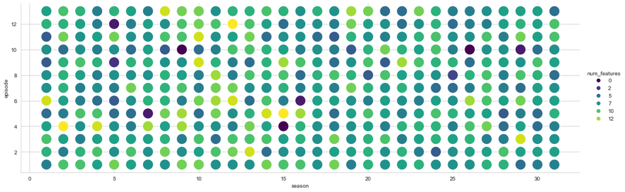

```python
sns.set_style('whitegrid')

sns.relplot(data = episode_info, x='season', y='episode', hue='num_features',
            aspect=3, s=400, palette='viridis')

plt.show()
```

Create a column if ZERO features are present.

```python
episode_info['zero_features'] = np.where(episode_info.num_features == 0, 'ZERO', 'non-zero')
```

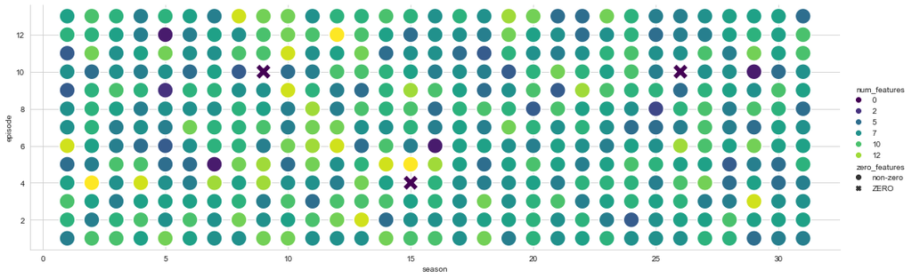

```python
sns.relplot(data = episode_info, x='season', y='episode', hue='num_features', style='zero_features',
            aspect=3, s=400, palette='viridis')

plt.show()
```

### Which artists are associated with zero features?

Can we find the artists with zero features based on the summarize episode data se?

```python
episode_info
```

|  | season | episode | possible_features | num_features | zero_features |
| --- | --- | --- | --- | --- | --- |
| 0 | 1 | 1 | 64 | 6 | non-zero |
| 1 | 1 | 2 | 64 | 9 | non-zero |
| 2 | 1 | 3 | 64 | 10 | non-zero |
| 3 | 1 | 4 | 64 | 8 | non-zero |
| 4 | 1 | 5 | 64 | 5 | non-zero |
| ... | ... | ... | ... | ... | ... |
| 398 | 31 | 9 | 64 | 8 | non-zero |
| 399 | 31 | 10 | 64 | 7 | non-zero |
| 400 | 31 | 11 | 64 | 10 | non-zero |
| 401 | 31 | 12 | 64 | 10 | non-zero |
| 402 | 31 | 13 | 64 | 5 | non-zero |

403 rows × 5 columns

Can we identify the artist based on the artist per episode data set?

```python
artist_per_episode
```

|  | season | episode | artist |
| --- | --- | --- | --- |
| 0 | 1 | 1 | BOB_ROSS |
| 1 | 1 | 2 | BOB_ROSS |
| 2 | 1 | 3 | BOB_ROSS |
| 3 | 1 | 4 | BOB_ROSS |
| 4 | 1 | 5 | BOB_ROSS |
| ... | ... | ... | ... |
| 398 | 31 | 9 | BOB_ROSS |
| 399 | 31 | 10 | BOB_ROSS |
| 400 | 31 | 11 | STEVE_ROSS |
| 401 | 31 | 12 | BOB_ROSS |
| 402 | 31 | 13 | BOB_ROSS |

403 rows × 3 columns

We must **JOIN** or **MERGE** the data sets to find out who painted the zero-feature paintings.

## JOIN or MERGE

We need to use either the `pd.merge()` function or the `.merge()` method associated with a DataFrame object.

Basic syntax of joining is based on **LEFT** and **RIGHT** data sets.

`pd.merge( <LEFT data>, <RIGHT data>, on=<KEYS>, how=<HOW to join?> )`

I like to think the **LEFT** data set as the LARGER data that we are joining a smaller data set to.

The `on` argument corresponds to **SHARED VARIABLES** or **SHARED COLUMNS** that exist in both data sets.

```python
episode_info
```

|  | season | episode | possible_features | num_features | zero_features |
| --- | --- | --- | --- | --- | --- |
| 0 | 1 | 1 | 64 | 6 | non-zero |
| 1 | 1 | 2 | 64 | 9 | non-zero |
| 2 | 1 | 3 | 64 | 10 | non-zero |
| 3 | 1 | 4 | 64 | 8 | non-zero |
| 4 | 1 | 5 | 64 | 5 | non-zero |
| ... | ... | ... | ... | ... | ... |
| 398 | 31 | 9 | 64 | 8 | non-zero |
| 399 | 31 | 10 | 64 | 7 | non-zero |
| 400 | 31 | 11 | 64 | 10 | non-zero |
| 401 | 31 | 12 | 64 | 10 | non-zero |
| 402 | 31 | 13 | 64 | 5 | non-zero |

403 rows × 5 columns

```python
artist_per_episode
```

|  | season | episode | artist |
| --- | --- | --- | --- |
| 0 | 1 | 1 | BOB_ROSS |
| 1 | 1 | 2 | BOB_ROSS |
| 2 | 1 | 3 | BOB_ROSS |
| 3 | 1 | 4 | BOB_ROSS |
| 4 | 1 | 5 | BOB_ROSS |
| ... | ... | ... | ... |
| 398 | 31 | 9 | BOB_ROSS |
| 399 | 31 | 10 | BOB_ROSS |
| 400 | 31 | 11 | STEVE_ROSS |
| 401 | 31 | 12 | BOB_ROSS |
| 402 | 31 | 13 | BOB_ROSS |

403 rows × 3 columns

```python
pd.merge( episode_info, artist_per_episode, on=['season', 'episode'], how='left' )
```

|  | season | episode | possible_features | num_features | zero_features | artist |
| --- | --- | --- | --- | --- | --- | --- |
| 0 | 1 | 1 | 64 | 6 | non-zero | BOB_ROSS |
| 1 | 1 | 2 | 64 | 9 | non-zero | BOB_ROSS |
| 2 | 1 | 3 | 64 | 10 | non-zero | BOB_ROSS |
| 3 | 1 | 4 | 64 | 8 | non-zero | BOB_ROSS |
| 4 | 1 | 5 | 64 | 5 | non-zero | BOB_ROSS |
| ... | ... | ... | ... | ... | ... | ... |
| 398 | 31 | 9 | 64 | 8 | non-zero | BOB_ROSS |
| 399 | 31 | 10 | 64 | 7 | non-zero | BOB_ROSS |
| 400 | 31 | 11 | 64 | 10 | non-zero | STEVE_ROSS |
| 401 | 31 | 12 | 64 | 10 | non-zero | BOB_ROSS |
| 402 | 31 | 13 | 64 | 5 | non-zero | BOB_ROSS |

403 rows × 6 columns

```python
episode_info_left = pd.merge( episode_info, artist_per_episode, on=['season', 'episode'], how='left' )
```

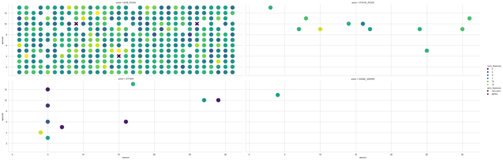

```python
sns.relplot(data = episode_info_left, x='season', y='episode', hue='num_features', style='zero_features',
            col='artist', col_wrap=2,
            aspect=3, s=400, palette='viridis')

plt.show()
```

Calculate the number of episodes per artist with zero features in this data set using a user defined function.

```python
def find_zero_features(zv):
    return zv.isin(['ZERO']).sum()
```

```python
episode_info_left.zero_features.isin(['ZERO']).sum()
```

```
3
```

```python
artist_per_season = episode_info_left.groupby(['season', 'artist']).\
aggregate(num_episodes = ('episode', 'nunique'),
          in_episodes = ('episode', 'unique'),
          min_features = ('num_features', 'min'),
          max_features = ('num_features', 'max'),
          avg_features = ('num_features', 'mean'),
          count_zero_features = ('zero_features', find_zero_features)).\
reset_index()
```

```python
artist_per_season
```

|  | season | artist | num_episodes | in_episodes | min_features | max_features | avg_features | count_zero_features |
| --- | --- | --- | --- | --- | --- | --- | --- | --- |
| 0 | 1 | BOB_ROSS | 13 | [1, 2, 3, 4, 5, 6, 7, 8, 9, 10, 11, 12, 13] | 4 | 13 | 7.461538 | 0 |
| 1 | 2 | BOB_ROSS | 13 | [1, 2, 3, 4, 5, 6, 7, 8, 9, 10, 11, 12, 13] | 5 | 14 | 8.769231 | 0 |
| 2 | 3 | BOB_ROSS | 12 | [1, 2, 3, 4, 5, 6, 7, 8, 9, 10, 11, 12] | 6 | 10 | 7.833333 | 0 |
| 3 | 3 | STEVE_ROSS | 1 | [13] | 9 | 9 | 9.000000 | 0 |
| 4 | 4 | BOB_ROSS | 11 | [1, 2, 3, 5, 6, 7, 8, 9, 10, 12, 13] | 5 | 10 | 7.363636 | 0 |
| 5 | 4 | DIANE_ANDRE | 1 | [11] | 8 | 8 | 8.000000 | 0 |
| 6 | 4 | OTHER | 1 | [4] | 13 | 13 | 13.000000 | 0 |
| 7 | 5 | BOB_ROSS | 9 | [1, 2, 4, 5, 7, 8, 10, 11, 13] | 5 | 11 | 7.777778 | 0 |
| 8 | 5 | OTHER | 4 | [3, 6, 9, 12] | 1 | 8 | 3.750000 | 0 |
| 9 | 6 | BOB_ROSS | 13 | [1, 2, 3, 4, 5, 6, 7, 8, 9, 10, 11, 12, 13] | 5 | 11 | 7.461538 | 0 |
| 10 | 7 | BOB_ROSS | 11 | [1, 2, 3, 4, 6, 7, 8, 10, 11, 12, 13] | 6 | 12 | 8.000000 | 0 |
| 11 | 7 | OTHER | 1 | [5] | 1 | 1 | 1.000000 | 0 |
| 12 | 7 | STEVE_ROSS | 1 | [9] | 9 | 9 | 9.000000 | 0 |
| 13 | 8 | BOB_ROSS | 12 | [1, 2, 3, 4, 5, 6, 7, 8, 9, 10, 12, 13] | 4 | 13 | 8.666667 | 0 |
| 14 | 8 | STEVE_ROSS | 1 | [11] | 10 | 10 | 10.000000 | 0 |
| 15 | 9 | BOB_ROSS | 13 | [1, 2, 3, 4, 5, 6, 7, 8, 9, 10, 11, 12, 13] | 0 | 12 | 8.461538 | 1 |
| 16 | 10 | BOB_ROSS | 12 | [1, 2, 3, 4, 5, 6, 7, 8, 10, 11, 12, 13] | 5 | 13 | 8.666667 | 0 |
| 17 | 10 | STEVE_ROSS | 1 | [9] | 13 | 13 | 13.000000 | 0 |
| 18 | 11 | BOB_ROSS | 13 | [1, 2, 3, 4, 5, 6, 7, 8, 9, 10, 11, 12, 13] | 5 | 12 | 8.769231 | 0 |
| 19 | 12 | BOB_ROSS | 13 | [1, 2, 3, 4, 5, 6, 7, 8, 9, 10, 11, 12, 13] | 6 | 14 | 9.076923 | 0 |
| 20 | 13 | BOB_ROSS | 13 | [1, 2, 3, 4, 5, 6, 7, 8, 9, 10, 11, 12, 13] | 5 | 13 | 9.000000 | 0 |
| 21 | 14 | BOB_ROSS | 12 | [1, 2, 3, 4, 5, 6, 7, 8, 9, 11, 12, 13] | 5 | 13 | 8.750000 | 0 |
| 22 | 14 | STEVE_ROSS | 1 | [10] | 9 | 9 | 9.000000 | 0 |
| 23 | 15 | BOB_ROSS | 13 | [1, 2, 3, 4, 5, 6, 7, 8, 9, 10, 11, 12, 13] | 0 | 14 | 8.076923 | 1 |
| 24 | 16 | BOB_ROSS | 11 | [1, 2, 3, 4, 5, 7, 8, 9, 11, 12, 13] | 5 | 12 | 8.090909 | 0 |
| 25 | 16 | OTHER | 1 | [6] | 1 | 1 | 1.000000 | 0 |
| 26 | 16 | STEVE_ROSS | 1 | [10] | 6 | 6 | 6.000000 | 0 |
| 27 | 17 | BOB_ROSS | 11 | [1, 2, 3, 4, 5, 6, 7, 8, 10, 11, 12] | 5 | 9 | 7.272727 | 0 |
| 28 | 17 | OTHER | 1 | [13] | 9 | 9 | 9.000000 | 0 |
| 29 | 17 | STEVE_ROSS | 1 | [9] | 8 | 8 | 8.000000 | 0 |
| 30 | 18 | BOB_ROSS | 13 | [1, 2, 3, 4, 5, 6, 7, 8, 9, 10, 11, 12, 13] | 4 | 11 | 7.153846 | 0 |
| 31 | 19 | BOB_ROSS | 13 | [1, 2, 3, 4, 5, 6, 7, 8, 9, 10, 11, 12, 13] | 4 | 12 | 8.153846 | 0 |
| 32 | 20 | BOB_ROSS | 13 | [1, 2, 3, 4, 5, 6, 7, 8, 9, 10, 11, 12, 13] | 4 | 11 | 8.384615 | 0 |
| 33 | 21 | BOB_ROSS | 13 | [1, 2, 3, 4, 5, 6, 7, 8, 9, 10, 11, 12, 13] | 4 | 11 | 7.384615 | 0 |
| 34 | 22 | BOB_ROSS | 13 | [1, 2, 3, 4, 5, 6, 7, 8, 9, 10, 11, 12, 13] | 5 | 12 | 7.692308 | 0 |
| 35 | 23 | BOB_ROSS | 13 | [1, 2, 3, 4, 5, 6, 7, 8, 9, 10, 11, 12, 13] | 6 | 11 | 8.153846 | 0 |
| 36 | 24 | BOB_ROSS | 12 | [1, 2, 3, 4, 5, 6, 7, 8, 10, 11, 12, 13] | 4 | 10 | 8.083333 | 0 |
| 37 | 24 | STEVE_ROSS | 1 | [9] | 9 | 9 | 9.000000 | 0 |
| 38 | 25 | BOB_ROSS | 12 | [1, 2, 3, 4, 6, 7, 8, 9, 10, 11, 12, 13] | 3 | 9 | 6.333333 | 0 |
| 39 | 25 | STEVE_ROSS | 1 | [5] | 9 | 9 | 9.000000 | 0 |
| 40 | 26 | BOB_ROSS | 13 | [1, 2, 3, 4, 5, 6, 7, 8, 9, 10, 11, 12, 13] | 0 | 12 | 7.153846 | 1 |
| 41 | 27 | BOB_ROSS | 12 | [1, 2, 3, 4, 5, 6, 7, 8, 9, 11, 12, 13] | 6 | 11 | 8.666667 | 0 |
| 42 | 27 | OTHER | 1 | [10] | 7 | 7 | 7.000000 | 0 |
| 43 | 28 | BOB_ROSS | 13 | [1, 2, 3, 4, 5, 6, 7, 8, 9, 10, 11, 12, 13] | 4 | 10 | 7.000000 | 0 |
| 44 | 29 | BOB_ROSS | 12 | [1, 2, 3, 4, 5, 6, 7, 8, 9, 11, 12, 13] | 5 | 13 | 8.416667 | 0 |
| 45 | 29 | OTHER | 1 | [10] | 1 | 1 | 1.000000 | 0 |
| 46 | 30 | BOB_ROSS | 12 | [1, 2, 3, 4, 5, 6, 7, 8, 10, 11, 12, 13] | 5 | 9 | 7.083333 | 0 |
| 47 | 30 | STEVE_ROSS | 1 | [9] | 10 | 10 | 10.000000 | 0 |
| 48 | 31 | BOB_ROSS | 12 | [1, 2, 3, 4, 5, 6, 7, 8, 9, 10, 12, 13] | 5 | 10 | 7.166667 | 0 |
| 49 | 31 | STEVE_ROSS | 1 | [11] | 10 | 10 | 10.000000 | 0 |

## How can we handle the missing episodes via JOINS?

### OR...what does the HOW mean in pd.merge()?

We removed all rows from `features_lf` that had `.value == 0`. The `present_features` DataFrame ONLY had the features present in the episode and so we **LOST** episodes that mistakenly had zero features identified in the original data set.

```python
present_features
```

|  | season | episode | feature | value |
| --- | --- | --- | --- | --- |
| 0 | 1 | 1 | BUSHES | 1 |
| 1 | 1 | 1 | DECIDUOUS | 1 |
| 2 | 1 | 1 | GRASS | 1 |
| 3 | 1 | 1 | RIVER | 1 |
| 4 | 1 | 1 | TREE | 1 |
| ... | ... | ... | ... | ... |
| 3182 | 31 | 13 | DECIDUOUS | 1 |
| 3183 | 31 | 13 | GRASS | 1 |
| 3184 | 31 | 13 | MOUNTAIN | 1 |
| 3185 | 31 | 13 | TREE | 1 |
| 3186 | 31 | 13 | TREES | 1 |

3187 rows × 4 columns

```python
artist_per_episode
```

|  | season | episode | artist |
| --- | --- | --- | --- |
| 0 | 1 | 1 | BOB_ROSS |
| 1 | 1 | 2 | BOB_ROSS |
| 2 | 1 | 3 | BOB_ROSS |
| 3 | 1 | 4 | BOB_ROSS |
| 4 | 1 | 5 | BOB_ROSS |
| ... | ... | ... | ... |
| 398 | 31 | 9 | BOB_ROSS |
| 399 | 31 | 10 | BOB_ROSS |
| 400 | 31 | 11 | STEVE_ROSS |
| 401 | 31 | 12 | BOB_ROSS |
| 402 | 31 | 13 | BOB_ROSS |

403 rows × 3 columns

Let's change **HOW** we join and see the impact on the number of rows in the joined data set.

### LEFT JOIN

Again I like to think of the **LEFT** data set as the **LARGER** of the two data sets.

```python
left_join_df = pd.merge( present_features, artist_per_episode, on=['season', 'episode'], how='left' )
```

```python
left_join_df
```

|  | season | episode | feature | value | artist |
| --- | --- | --- | --- | --- | --- |
| 0 | 1 | 1 | BUSHES | 1 | BOB_ROSS |
| 1 | 1 | 1 | DECIDUOUS | 1 | BOB_ROSS |
| 2 | 1 | 1 | GRASS | 1 | BOB_ROSS |
| 3 | 1 | 1 | RIVER | 1 | BOB_ROSS |
| 4 | 1 | 1 | TREE | 1 | BOB_ROSS |
| ... | ... | ... | ... | ... | ... |
| 3182 | 31 | 13 | DECIDUOUS | 1 | BOB_ROSS |
| 3183 | 31 | 13 | GRASS | 1 | BOB_ROSS |
| 3184 | 31 | 13 | MOUNTAIN | 1 | BOB_ROSS |
| 3185 | 31 | 13 | TREE | 1 | BOB_ROSS |
| 3186 | 31 | 13 | TREES | 1 | BOB_ROSS |

3187 rows × 5 columns

### RIGHT JOIN

```python
right_join_df = pd.merge( present_features, artist_per_episode, on=['season', 'episode'], how='right')
```

```python
right_join_df
```

|  | season | episode | feature | value | artist |
| --- | --- | --- | --- | --- | --- |
| 0 | 1 | 1 | BUSHES | 1.0 | BOB_ROSS |
| 1 | 1 | 1 | DECIDUOUS | 1.0 | BOB_ROSS |
| 2 | 1 | 1 | GRASS | 1.0 | BOB_ROSS |
| 3 | 1 | 1 | RIVER | 1.0 | BOB_ROSS |
| 4 | 1 | 1 | TREE | 1.0 | BOB_ROSS |
| ... | ... | ... | ... | ... | ... |
| 3185 | 31 | 13 | DECIDUOUS | 1.0 | BOB_ROSS |
| 3186 | 31 | 13 | GRASS | 1.0 | BOB_ROSS |
| 3187 | 31 | 13 | MOUNTAIN | 1.0 | BOB_ROSS |
| 3188 | 31 | 13 | TREE | 1.0 | BOB_ROSS |
| 3189 | 31 | 13 | TREES | 1.0 | BOB_ROSS |

3190 rows × 5 columns

**WHY?!?!?!?** do we get different rows based on the **HOW** we join the two data sets?

```python
left_join_df.isna().sum()
```

```
season     0
episode    0
feature    0
value      0
artist     0
dtype: int64
```

```python
right_join_df.isna().sum()
```

```
season     0
episode    0
feature    3
value      3
artist     0
dtype: int64
```

The **RIGHT** data set has ALL episodes.

```python
artist_per_episode.loc[ (artist_per_episode.season == 9) & (artist_per_episode.episode.isin([9, 10, 11])) ]
```

|  | season | episode | artist |
| --- | --- | --- | --- |
| 112 | 9 | 9 | BOB_ROSS |
| 113 | 9 | 10 | BOB_ROSS |
| 114 | 9 | 11 | BOB_ROSS |

The **LEFT** data set has episodes not contained within the data set.

```python
present_features.loc[ (present_features.season == 9) & (present_features.episode.isin([9, 10, 11])) ]
```

|  | season | episode | feature | value |
| --- | --- | --- | --- | --- |
| 882 | 9 | 9 | BUSHES | 1 |
| 883 | 9 | 9 | CLOUDS | 1 |
| 884 | 9 | 9 | MOUNTAIN | 1 |
| 885 | 9 | 9 | RIVER | 1 |
| 886 | 9 | 9 | SNOWY_MOUNTAIN | 1 |
| 887 | 9 | 9 | TREE | 1 |
| 888 | 9 | 9 | TREES | 1 |
| 889 | 9 | 11 | BUSHES | 1 |
| 890 | 9 | 11 | CLOUDS | 1 |
| 891 | 9 | 11 | CUMULUS | 1 |
| 892 | 9 | 11 | DECIDUOUS | 1 |
| 893 | 9 | 11 | GRASS | 1 |
| 894 | 9 | 11 | MOUNTAIN | 1 |
| 895 | 9 | 11 | MOUNTAINS | 1 |
| 896 | 9 | 11 | RIVER | 1 |
| 897 | 9 | 11 | TREE | 1 |
| 898 | 9 | 11 | TREES | 1 |

Look at the LEFT JOINED object...

```python
left_join_df.loc[ (left_join_df.season == 9) & (left_join_df.episode.isin([9, 10, 11])) ]
```

|  | season | episode | feature | value | artist |
| --- | --- | --- | --- | --- | --- |
| 882 | 9 | 9 | BUSHES | 1 | BOB_ROSS |
| 883 | 9 | 9 | CLOUDS | 1 | BOB_ROSS |
| 884 | 9 | 9 | MOUNTAIN | 1 | BOB_ROSS |
| 885 | 9 | 9 | RIVER | 1 | BOB_ROSS |
| 886 | 9 | 9 | SNOWY_MOUNTAIN | 1 | BOB_ROSS |
| 887 | 9 | 9 | TREE | 1 | BOB_ROSS |
| 888 | 9 | 9 | TREES | 1 | BOB_ROSS |
| 889 | 9 | 11 | BUSHES | 1 | BOB_ROSS |
| 890 | 9 | 11 | CLOUDS | 1 | BOB_ROSS |
| 891 | 9 | 11 | CUMULUS | 1 | BOB_ROSS |
| 892 | 9 | 11 | DECIDUOUS | 1 | BOB_ROSS |
| 893 | 9 | 11 | GRASS | 1 | BOB_ROSS |
| 894 | 9 | 11 | MOUNTAIN | 1 | BOB_ROSS |
| 895 | 9 | 11 | MOUNTAINS | 1 | BOB_ROSS |
| 896 | 9 | 11 | RIVER | 1 | BOB_ROSS |
| 897 | 9 | 11 | TREE | 1 | BOB_ROSS |
| 898 | 9 | 11 | TREES | 1 | BOB_ROSS |

Look at the RIGHT JOINED object...

```python
right_join_df.loc[ (right_join_df.season == 9) & (right_join_df.episode.isin([9, 10, 11])) ]
```

|  | season | episode | feature | value | artist |
| --- | --- | --- | --- | --- | --- |
| 882 | 9 | 9 | BUSHES | 1.0 | BOB_ROSS |
| 883 | 9 | 9 | CLOUDS | 1.0 | BOB_ROSS |
| 884 | 9 | 9 | MOUNTAIN | 1.0 | BOB_ROSS |
| 885 | 9 | 9 | RIVER | 1.0 | BOB_ROSS |
| 886 | 9 | 9 | SNOWY_MOUNTAIN | 1.0 | BOB_ROSS |
| 887 | 9 | 9 | TREE | 1.0 | BOB_ROSS |
| 888 | 9 | 9 | TREES | 1.0 | BOB_ROSS |
| 889 | 9 | 10 | NaN | NaN | BOB_ROSS |
| 890 | 9 | 11 | BUSHES | 1.0 | BOB_ROSS |
| 891 | 9 | 11 | CLOUDS | 1.0 | BOB_ROSS |
| 892 | 9 | 11 | CUMULUS | 1.0 | BOB_ROSS |
| 893 | 9 | 11 | DECIDUOUS | 1.0 | BOB_ROSS |
| 894 | 9 | 11 | GRASS | 1.0 | BOB_ROSS |
| 895 | 9 | 11 | MOUNTAIN | 1.0 | BOB_ROSS |
| 896 | 9 | 11 | MOUNTAINS | 1.0 | BOB_ROSS |
| 897 | 9 | 11 | RIVER | 1.0 | BOB_ROSS |
| 898 | 9 | 11 | TREE | 1.0 | BOB_ROSS |
| 899 | 9 | 11 | TREES | 1.0 | BOB_ROSS |

### INNER JOIN

This is the default option in `pd.merge()`.

The KEY values are shared between the two data sets.

```python
inner_join_df = pd.merge( present_features, artist_per_episode, on=['season', 'episode'], how='inner' )
```

```python
inner_join_df
```

|  | season | episode | feature | value | artist |
| --- | --- | --- | --- | --- | --- |
| 0 | 1 | 1 | BUSHES | 1 | BOB_ROSS |
| 1 | 1 | 1 | DECIDUOUS | 1 | BOB_ROSS |
| 2 | 1 | 1 | GRASS | 1 | BOB_ROSS |
| 3 | 1 | 1 | RIVER | 1 | BOB_ROSS |
| 4 | 1 | 1 | TREE | 1 | BOB_ROSS |
| ... | ... | ... | ... | ... | ... |
| 3182 | 31 | 13 | DECIDUOUS | 1 | BOB_ROSS |
| 3183 | 31 | 13 | GRASS | 1 | BOB_ROSS |
| 3184 | 31 | 13 | MOUNTAIN | 1 | BOB_ROSS |
| 3185 | 31 | 13 | TREE | 1 | BOB_ROSS |
| 3186 | 31 | 13 | TREES | 1 | BOB_ROSS |

3187 rows × 5 columns

### OUTER JOIN

Keeps ALL unique combinations of the KEYS in both data sets. The outer join is also called a **FULL** join.

```python
outer_join_df = pd.merge( present_features, artist_per_episode, on=['season', 'episode'], how='outer')
```

```python
outer_join_df
```

|  | season | episode | feature | value | artist |
| --- | --- | --- | --- | --- | --- |
| 0 | 1 | 1 | BUSHES | 1.0 | BOB_ROSS |
| 1 | 1 | 1 | DECIDUOUS | 1.0 | BOB_ROSS |
| 2 | 1 | 1 | GRASS | 1.0 | BOB_ROSS |
| 3 | 1 | 1 | RIVER | 1.0 | BOB_ROSS |
| 4 | 1 | 1 | TREE | 1.0 | BOB_ROSS |
| ... | ... | ... | ... | ... | ... |
| 3185 | 31 | 13 | TREE | 1.0 | BOB_ROSS |
| 3186 | 31 | 13 | TREES | 1.0 | BOB_ROSS |
| 3187 | 9 | 10 | NaN | NaN | BOB_ROSS |
| 3188 | 15 | 4 | NaN | NaN | BOB_ROSS |
| 3189 | 26 | 10 | NaN | NaN | BOB_ROSS |

3190 rows × 5 columns

### For this specific example...

The LEFT JOIN and INNER JOIN are the same.

```python
inner_join_df.equals( left_join_df )
```

```
True
```

The RIGHT JOIN and the OUTER JOIN yield the same result...

```python
outer_join_df.sort_values(['season', 'episode'], inplace=True, ignore_index=True)
```

```python
outer_join_df.equals( right_join_df )
```

```
True
```

## Final Tidy Data set

Just which type of join we should use...**DEPENDS ON THE CONTEXT**.

For this specific application...we want an OUTER JOIN. We can drop the `value` column because it is redundant.

```python
tidy_df = outer_join_df.copy().drop(columns=['value'])
```

```python
tidy_df
```

|  | season | episode | feature | artist |
| --- | --- | --- | --- | --- |
| 0 | 1 | 1 | BUSHES | BOB_ROSS |
| 1 | 1 | 1 | DECIDUOUS | BOB_ROSS |
| 2 | 1 | 1 | GRASS | BOB_ROSS |
| 3 | 1 | 1 | RIVER | BOB_ROSS |
| 4 | 1 | 1 | TREE | BOB_ROSS |
| ... | ... | ... | ... | ... |
| 3185 | 31 | 13 | DECIDUOUS | BOB_ROSS |
| 3186 | 31 | 13 | GRASS | BOB_ROSS |
| 3187 | 31 | 13 | MOUNTAIN | BOB_ROSS |
| 3188 | 31 | 13 | TREE | BOB_ROSS |
| 3189 | 31 | 13 | TREES | BOB_ROSS |

3190 rows × 4 columns

## Summarize the final tidy data set

```python
def find_missing_features(fname):
    return fname.isna().any()
```

```python
episode_summary = tidy_df.groupby(['season', 'episode', 'artist']).\
aggregate(num_features = ('feature', 'nunique'),
          missing_features = ('feature', find_missing_features)).\
reset_index()
```

```python
episode_summary
```

|  | season | episode | artist | num_features | missing_features |
| --- | --- | --- | --- | --- | --- |
| 0 | 1 | 1 | BOB_ROSS | 6 | False |
| 1 | 1 | 2 | BOB_ROSS | 9 | False |
| 2 | 1 | 3 | BOB_ROSS | 10 | False |
| 3 | 1 | 4 | BOB_ROSS | 8 | False |
| 4 | 1 | 5 | BOB_ROSS | 5 | False |
| ... | ... | ... | ... | ... | ... |
| 398 | 31 | 9 | BOB_ROSS | 8 | False |
| 399 | 31 | 10 | BOB_ROSS | 7 | False |
| 400 | 31 | 11 | STEVE_ROSS | 10 | False |
| 401 | 31 | 12 | BOB_ROSS | 10 | False |
| 402 | 31 | 13 | BOB_ROSS | 5 | False |

403 rows × 5 columns

Which episodes have missing features?

```python
episode_summary.loc[ episode_summary.missing_features ]
```

|  | season | episode | artist | num_features | missing_features |
| --- | --- | --- | --- | --- | --- |
| 113 | 9 | 10 | BOB_ROSS | 0 | True |
| 185 | 15 | 4 | BOB_ROSS | 0 | True |
| 334 | 26 | 10 | BOB_ROSS | 0 | True |

### It's easy to add information

For example, what if we want "nicer" looking names for the artists.

```python
artist_info
```

|  | artist | num_episodes | num_seasons | first_season | last_season |
| --- | --- | --- | --- | --- | --- |
| 0 | BOB_ROSS | 381 | 31 | 1 | 31 |
| 1 | DIANE_ANDRE | 1 | 1 | 4 | 4 |
| 2 | OTHER | 10 | 7 | 4 | 29 |
| 3 | STEVE_ROSS | 11 | 11 | 3 | 31 |

```python
artist_info['artist_name'] = ['Bob Ross', 'Diane Andre', 'Other', 'Steve Ross']
```

```python
artist_info
```

|  | artist | num_episodes | num_seasons | first_season | last_season | artist_name |
| --- | --- | --- | --- | --- | --- | --- |
| 0 | BOB_ROSS | 381 | 31 | 1 | 31 | Bob Ross |
| 1 | DIANE_ANDRE | 1 | 1 | 4 | 4 | Diane Andre |
| 2 | OTHER | 10 | 7 | 4 | 29 | Other |
| 3 | STEVE_ROSS | 11 | 11 | 3 | 31 | Steve Ross |

```python
tidy_df
```

|  | season | episode | feature | artist |
| --- | --- | --- | --- | --- |
| 0 | 1 | 1 | BUSHES | BOB_ROSS |
| 1 | 1 | 1 | DECIDUOUS | BOB_ROSS |
| 2 | 1 | 1 | GRASS | BOB_ROSS |
| 3 | 1 | 1 | RIVER | BOB_ROSS |
| 4 | 1 | 1 | TREE | BOB_ROSS |
| ... | ... | ... | ... | ... |
| 3185 | 31 | 13 | DECIDUOUS | BOB_ROSS |
| 3186 | 31 | 13 | GRASS | BOB_ROSS |
| 3187 | 31 | 13 | MOUNTAIN | BOB_ROSS |
| 3188 | 31 | 13 | TREE | BOB_ROSS |
| 3189 | 31 | 13 | TREES | BOB_ROSS |

3190 rows × 4 columns

```python
tidy_df.merge( artist_info.loc[:, ['artist', 'artist_name']], on='artist', how='left')
```

|  | season | episode | feature | artist | artist_name |
| --- | --- | --- | --- | --- | --- |
| 0 | 1 | 1 | BUSHES | BOB_ROSS | Bob Ross |
| 1 | 1 | 1 | DECIDUOUS | BOB_ROSS | Bob Ross |
| 2 | 1 | 1 | GRASS | BOB_ROSS | Bob Ross |
| 3 | 1 | 1 | RIVER | BOB_ROSS | Bob Ross |
| 4 | 1 | 1 | TREE | BOB_ROSS | Bob Ross |
| ... | ... | ... | ... | ... | ... |
| 3185 | 31 | 13 | DECIDUOUS | BOB_ROSS | Bob Ross |
| 3186 | 31 | 13 | GRASS | BOB_ROSS | Bob Ross |
| 3187 | 31 | 13 | MOUNTAIN | BOB_ROSS | Bob Ross |
| 3188 | 31 | 13 | TREE | BOB_ROSS | Bob Ross |
| 3189 | 31 | 13 | TREES | BOB_ROSS | Bob Ross |

3190 rows × 5 columns

```python
tidy_df.merge( artist_info.loc[:, ['artist', 'artist_name']], on='artist', how='left').\
drop(columns=['artist'])
```

|  | season | episode | feature | artist_name |
| --- | --- | --- | --- | --- |
| 0 | 1 | 1 | BUSHES | Bob Ross |
| 1 | 1 | 1 | DECIDUOUS | Bob Ross |
| 2 | 1 | 1 | GRASS | Bob Ross |
| 3 | 1 | 1 | RIVER | Bob Ross |
| 4 | 1 | 1 | TREE | Bob Ross |
| ... | ... | ... | ... | ... |
| 3185 | 31 | 13 | DECIDUOUS | Bob Ross |
| 3186 | 31 | 13 | GRASS | Bob Ross |
| 3187 | 31 | 13 | MOUNTAIN | Bob Ross |
| 3188 | 31 | 13 | TREE | Bob Ross |
| 3189 | 31 | 13 | TREES | Bob Ross |

3190 rows × 4 columns